# Generate Sampling Distributions and CIs

Minsoo Joo

2025-03-04

# Challenge 1

## Step 1

```r
library(tidyverse)
```

Load the “IMDB-movies.csv” dataset.

```r
f<-"https://raw.githubusercontent.com/difiore/ada-datasets/main/IMDB-movies.csv"
d<-read_csv(f, col_names = TRUE)
```

## Step 2

Filter the dataset.

```r
d <- d %>%
  filter(startYear >= 1920 & startYear <=1979) %>%
  filter(runtimeMinutes >= 60 & runtimeMinutes <= 180) %>%
  mutate(decade = case_when((startYear >= 1920 & startYear < 1930) ~ '20s',
                            (startYear >= 1930 & startYear < 1940) ~ '30s',
                            (startYear >= 1940 & startYear < 1950) ~ '40s',
                            (startYear >= 1950 & startYear < 1960) ~ '50s',
                            (startYear >= 1960 & startYear < 1970) ~ '60s',
                            (startYear >= 1970 & startYear < 1980) ~ '70s'))
print(d)
```

```
## # A tibble: 5,651 × 11
##    tconst   titleType primaryTitle startYear runtimeMinutes genres averageRating
##    <chr>    <chr>     <chr>            <dbl>          <dbl> <chr>          <dbl>
##  1 tt00103… movie     The Cabinet…      1920             76 Fanta…           8.1
##  2 tt00110… movie     Leaves From…      1920            167 Drama            6.7
##  3 tt00111… movie     Dr. Jekyll …      1920             82 Drama…           7
##  4 tt00112… movie     The Golem         1920             76 Fanta…           7.2
##  5 tt00113… movie     The Last of…      1920             73 Actio…           6.7
##  6 tt00114… movie     The Mark of…      1920            107 Adven…           7.1
##  7 tt00115… movie     The Penalty       1920             90 Crime…           7.4
##  8 tt00116… movie     The Saphead       1920             77 Comedy           6.2
##  9 tt00118… movie     Way Down Ea…      1920            145 Drama…           7.4
## 10 tt00118… movie     Why Change …      1920             90 Comed…           6.7
## # ℹ 5,641 more rows
## # ℹ 4 more variables: numVotes <dbl>, nconst <chr>, director <chr>,
## #   decade <chr>
```

## Step 3

Plot histograms of the distribution of runtimeMinutes for each decade.

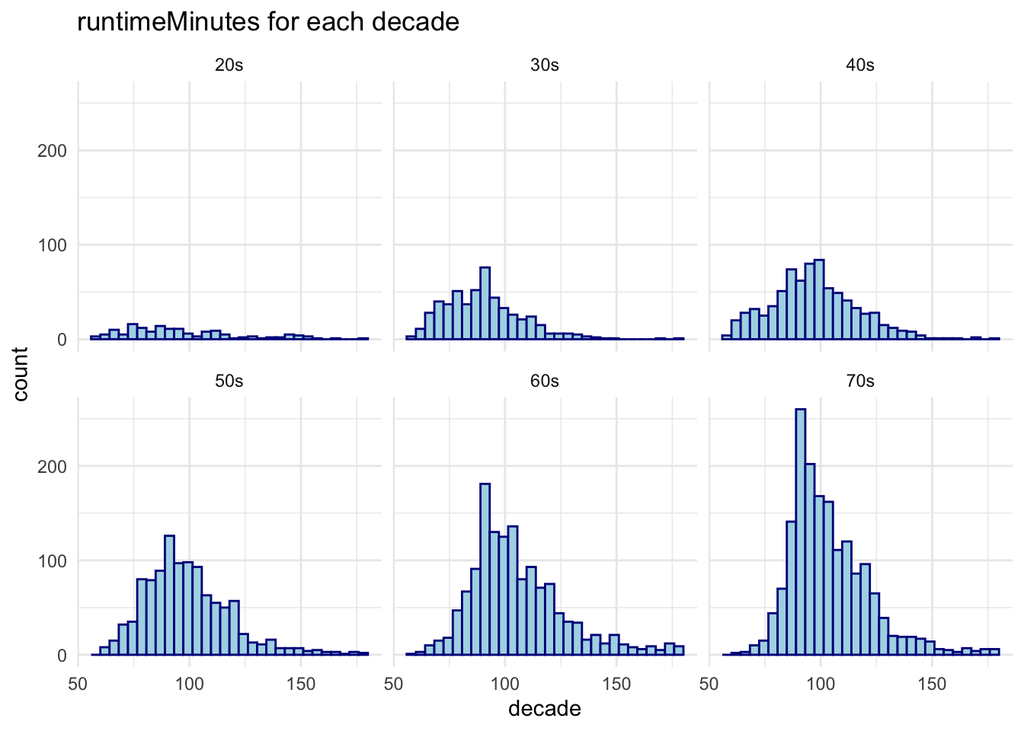

```r
ggplot(d, aes(x=runtimeMinutes)) +
  geom_histogram(color="darkblue", fill="lightblue") +
  facet_wrap(~decade) +
  labs(title="runtimeMinutes for each decade",x="decade", y = "count")+
  theme_minimal()
```

## Step 4

Calculate the population mean, population standard deviation, and population standard error.

```r
results <- d %>%
  group_by(decade) %>%
  summarise(pop_mean = mean(runtimeMinutes),
            pop_std = sqrt(sum((runtimeMinutes - mean(runtimeMinutes))**2) / n()),
            pop_SE = pop_std/sqrt(100))
results
```

```
## # A tibble: 6 × 4
##   decade pop_mean pop_std pop_SE
##   <chr>     <dbl>   <dbl>  <dbl>
## 1 20s        96.3    26.1   2.61
## 2 30s        90.3    17.3   1.73
## 3 40s        97.2    19.1   1.91
## 4 50s        98.9    19.2   1.92
## 5 60s       106.     21.2   2.12
## 6 70s       104.     18.0   1.80
```

## Step 5 & 6

Draw a sample (100 movies), from each decade and calculate the single sample mean, single sample standard deviation, and the standard error.

```r
results_sample <- d %>%
  group_by(decade) %>%
  sample_n(100, replace = FALSE) %>%
  summarise(sample_mean = mean(runtimeMinutes),
            sample_std = sd(runtimeMinutes),
            SE = sample_std/sqrt(100)) # Step 6
results_sample
```

```
## # A tibble: 6 × 4
##   decade sample_mean sample_std    SE
##   <chr>        <dbl>      <dbl> <dbl>
## 1 20s           94.9       23.2  2.32
## 2 30s           91.6       19.6  1.96
## 3 40s           96.2       20.5  2.05
## 4 50s          103.        20.2  2.02
## 5 60s          108.        21.7  2.17
## 6 70s          104.        19.6  1.96
```

## Step 7

The sample means, standard deviations, and standard error are close to the population means, with minor differences, indicating that the sample represents the population well.

```r
results$pop_mean - results_sample$sample_mean
```

```
## [1]  1.3165789 -1.3100000  0.9933248 -4.0418039 -2.2741414 -0.7200000
```

```r
results$pop_std - results_sample$sample_std
```

```
## [1]  2.9119815 -2.3259686 -1.3588881 -1.0436466 -0.4504718 -1.6208910
```

```r
results$pop_SE - results_sample$SE
```

```
## [1]  0.29119815 -0.23259686 -0.13588881 -0.10436466 -0.04504718 -0.16208910
```

## Step 8

Generate a sampling distribution of mean runtimeMinutes for each decade.

```r
library(mosaic)

sampling_distribution <- do(1000)* (
  d %>%
  group_by(decade) %>%
  sample_n(100, replace = FALSE) %>%
  summarise(sample_mean = mean(runtimeMinutes),
            sample_std = sd(runtimeMinutes))
  )

sampling_distribution
```

```
## # A tibble: 6,000 × 5
##    decade sample_mean sample_std  .row .index
##    <chr>        <dbl>      <dbl> <int>  <dbl>
##  1 20s           97.0       26.9     1      1
##  2 30s           90.7       17.3     2      1
##  3 40s           96.6       19.4     3      1
##  4 50s          100.        18.2     4      1
##  5 60s          107.        21.9     5      1
##  6 70s          106.        18.0     6      1
##  7 20s           99.3       27.0     1      2
##  8 30s           89.2       16.3     2      2
##  9 40s           95.8       17.5     3      2
## 10 50s           98.8       19.7     4      2
## # ℹ 5,990 more rows
```

## Step 9

Calculate the mean and the standard deviation of the sampling distribution of sample means.

```r
results_sampling_distribution <- sampling_distribution %>%
  group_by(decade) %>%
  summarise(mean = mean(sample_mean),
            std = sd(sample_mean))

results_sampling_distribution
```

```
## # A tibble: 6 × 3
##   decade  mean   std
##   <chr>  <dbl> <dbl>
## 1 20s     96.3  1.56
## 2 30s     90.3  1.55
## 3 40s     97.1  1.75
## 4 50s     98.9  1.80
## 5 60s    106.   2.10
## 6 70s    104.   1.72
```

Plot a histogram of the sampling distribution for each decade.

Those seem like normal distributions—bell-shaped and symmetric.

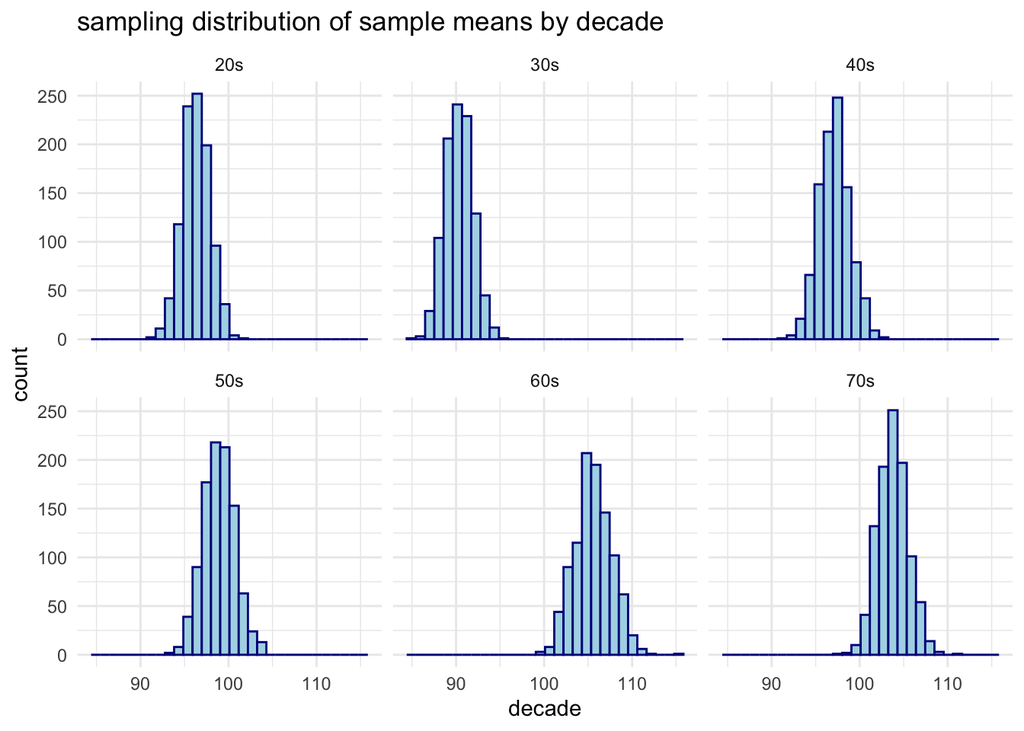

```r
ggplot(sampling_distribution, aes(x=sample_mean)) +
  geom_histogram(color="darkblue", fill="lightblue") +
  facet_wrap(~decade) +
  labs(title="sampling distribution of sample means by decade", x="decade")+
  theme_minimal()
```

## Step 10

Population SE (pop_SE) is the most accurate theoretically but often unavailable in real studies. Single Sample SE (sample_SE) closely matches pop_SE, though it depends on the chosen sample. Sampling Distribution SE (std) represents the variability of sample means but tends to be smaller than pop_SE due to reduced variance in averages.

In this case, sample_SE best approximates pop_SE.

```r
results$pop_SE
```

```
## [1] 2.611500 1.727247 1.911149 1.919757 2.122436 1.795412
```

```r
results_sample$SE
```

```
## [1] 2.320302 1.959844 2.047038 2.024122 2.167483 1.957501
```

```r
results_sampling_distribution$std
```

```
## [1] 1.558412 1.545820 1.745706 1.799803 2.095882 1.721443
```

```r
results_sample$SE - results$pop_SE
```

```
## [1] -0.29119815  0.23259686  0.13588881  0.10436466  0.04504718  0.16208910
```

```r
results_sample$SE - results_sampling_distribution$std
```

```
## [1] 0.76188996 0.41402399 0.30133181 0.22431868 0.07160085 0.23605761
```

# Challenge 2

## Step 1

Load the “zombies.csv” dataset.

```r
f<-"https://raw.githubusercontent.com/difiore/ada-datasets/main/zombies.csv"
z<-read_csv(f, col_names = TRUE)
```

## Step 2

Calculate the population mean and standard deviation.

```r
pop_stdv <- function(x){
  s<-sqrt(sum((x-mean(x))**2)/length(x))
  return(s)
}

z_stat <- z %>%
  summarise(across(c(height,weight,age,zombies_killed,years_of_education),
                   list(pop_mean = mean, pop_sd = pop_stdv)))

t(z_stat)
```

```
##                                   [,1]
## height_pop_mean              67.630098
## height_pop_sd                 4.307970
## weight_pop_mean             143.907478
## weight_pop_sd                18.391857
## age_pop_mean                 20.046961
## age_pop_sd                    2.963583
## zombies_killed_pop_mean       2.992000
## zombies_killed_pop_sd         1.747551
## years_of_education_pop_mean   2.996000
## years_of_education_pop_sd     1.675704
```

## Step 3

Make boxplots of each of these variables by gender.

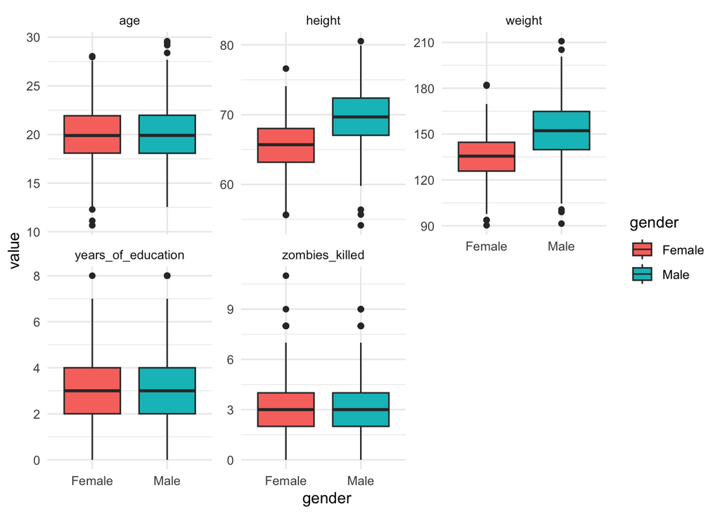

```r
z %>%
  select(c(gender,height,weight,age,zombies_killed,years_of_education)) %>%
  pivot_longer(cols = -gender, names_to = "variable", values_to = "value") %>%
  ggplot(aes(x = gender, y = value, fill = gender)) +
  geom_boxplot() +
  facet_wrap(~ variable, scales = "free_y") +
  theme_minimal()
```

## Step 4

Use {ggplot} and make scatterplots of height and weight in relation to age (i.e., use age as the variable), using different colored points for males versus females. Do these variables seem to be related? In what way?

There seems a positive correlation between age and height. The relationship between age and weight is less clear.

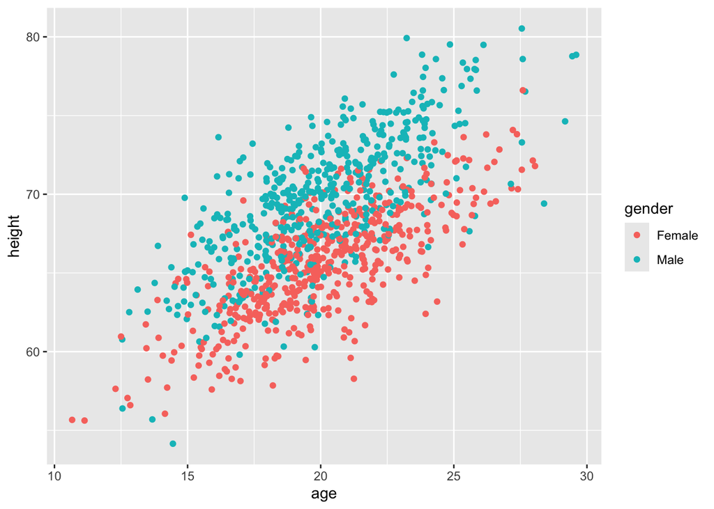

```r
ggplot(z, aes(x = age, y = height, color = gender)) +
  geom_point()
```

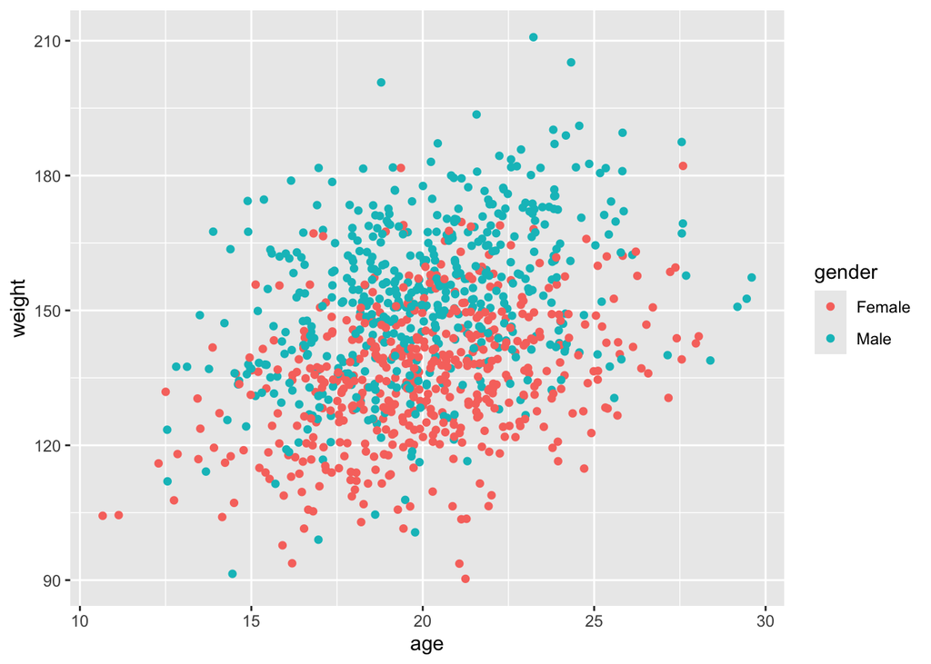

```r
ggplot(z, aes(x = age, y = weight, color = gender)) +
  geom_point()
```

## Step 5

Using histograms and Q-Q plots, check whether each of the quantitative variables seem to be drawn from a normal distribution. Which seem to be and which do not? Height, Weight, and Age show approximately normal distributions. Zombies Killed and Years of Education appears discrete and non-normal.

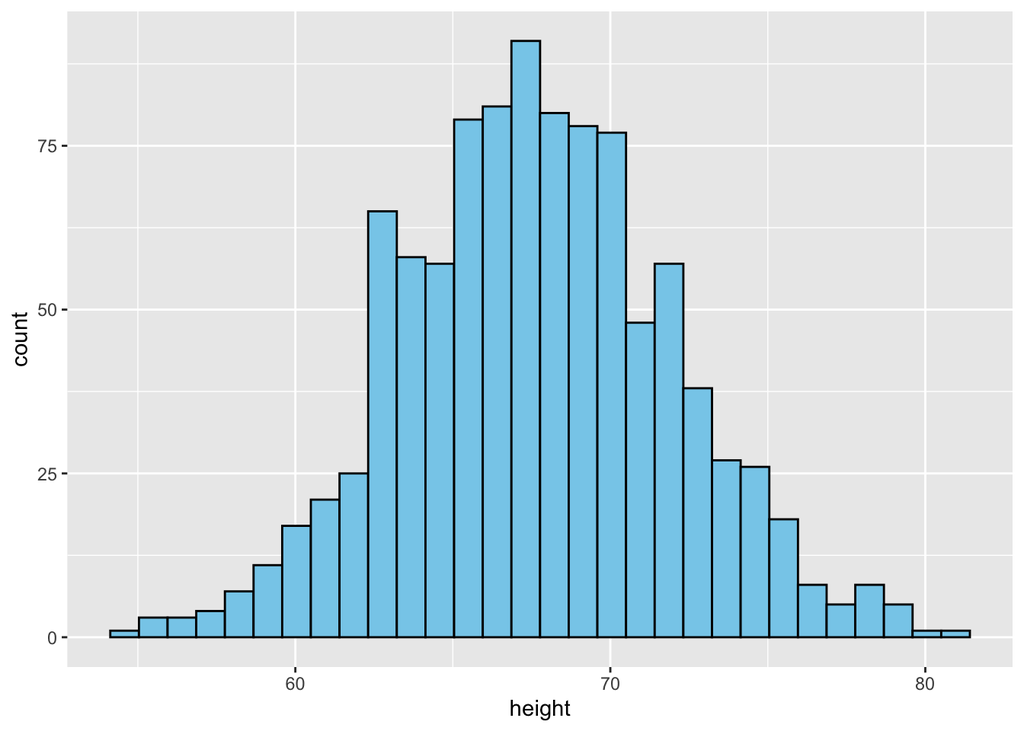

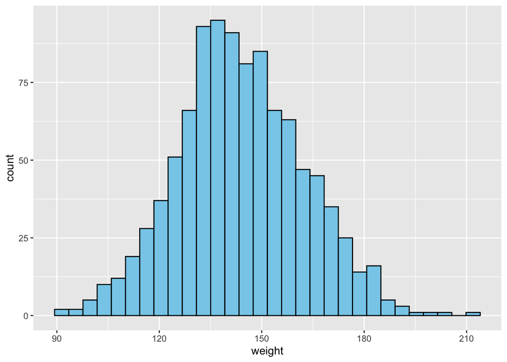

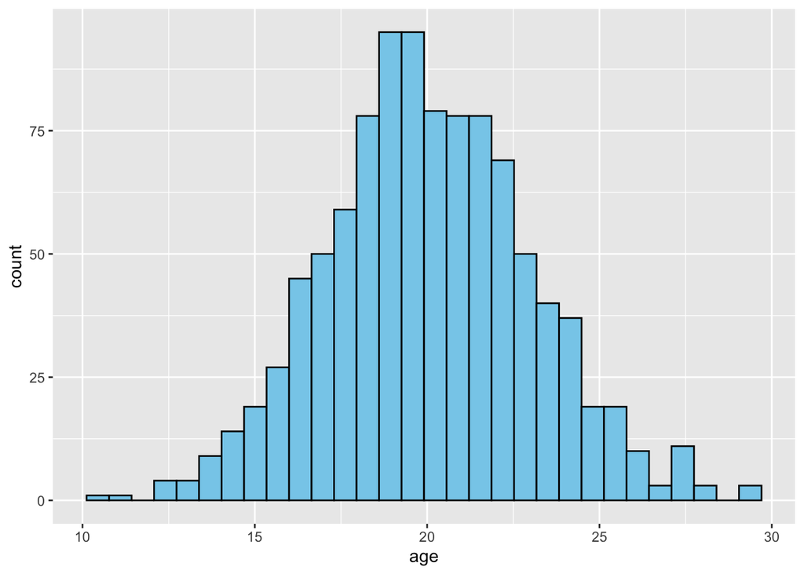

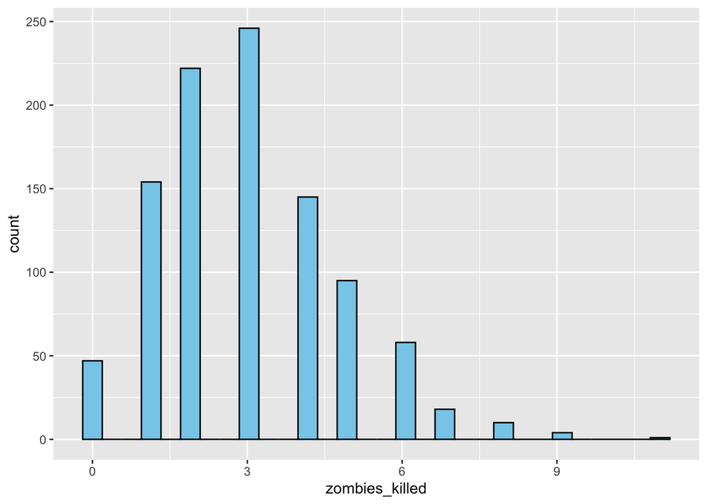

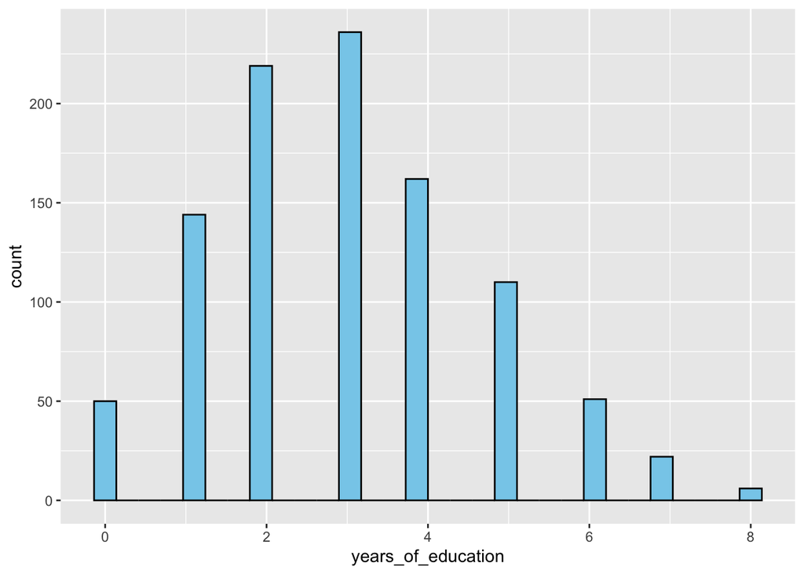

```r
variables <- c("height", "weight", "age", "zombies_killed", "years_of_education")
for (var in variables){
  print(
    ggplot(z, aes(x = .data[[var]])) +
      geom_histogram(fill = "skyblue", color = "black")
  )
}
```

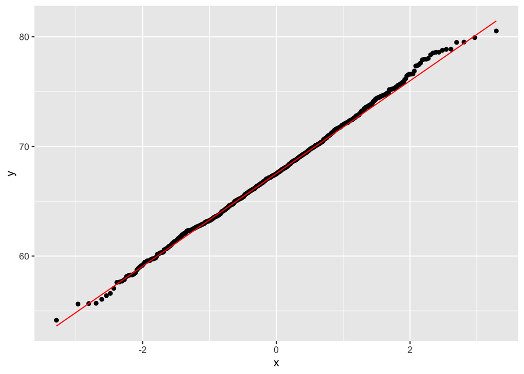

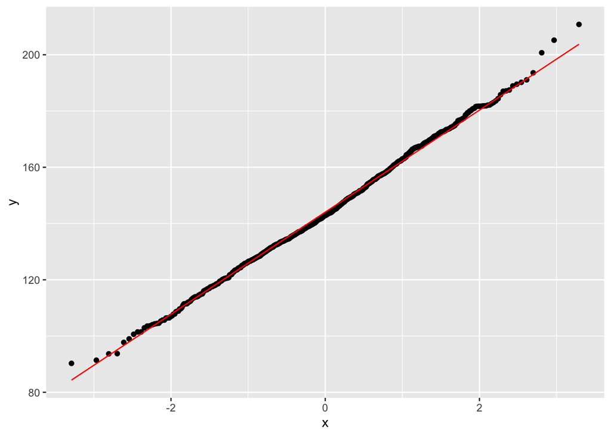

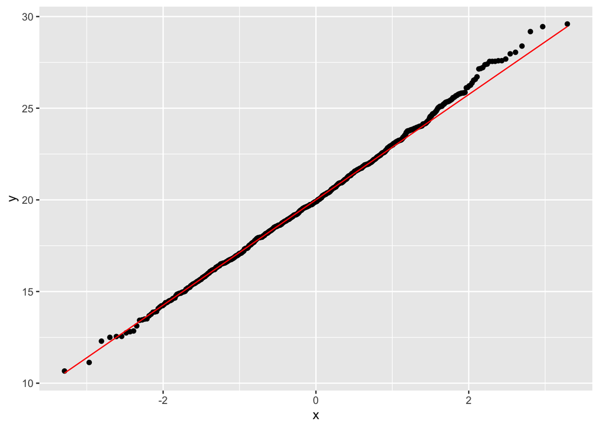

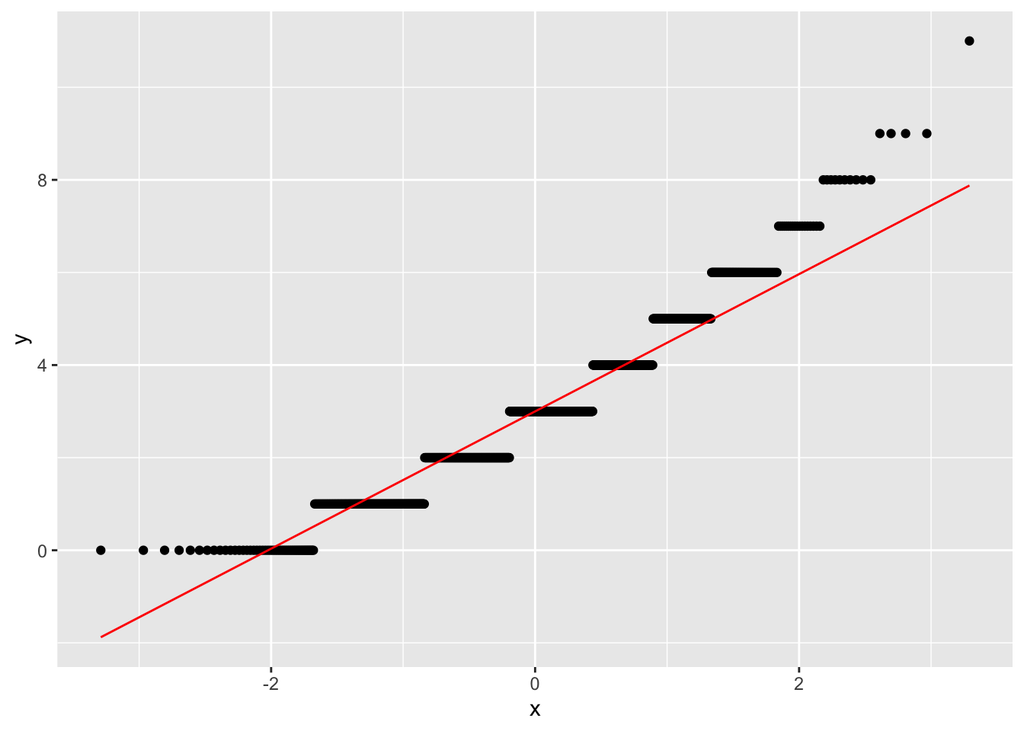

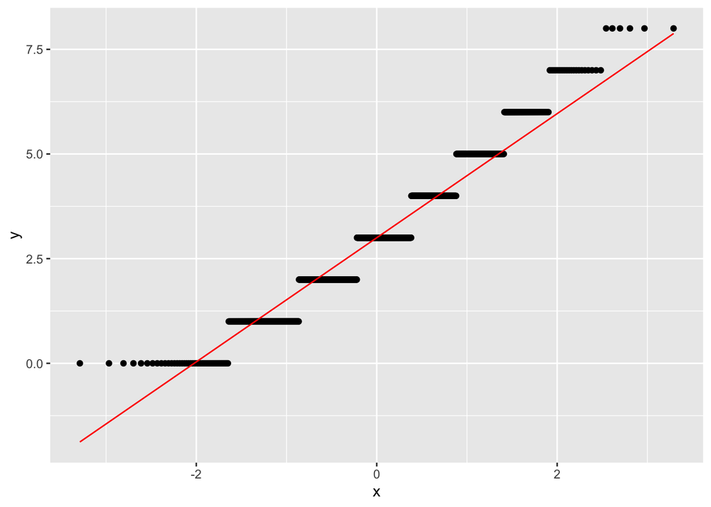

```r
for (var in variables){
  print(
  ggplot(z, aes(sample = .data[[var]])) +
    stat_qq() +
    stat_qq_line(color = "red")
  )
}
```

## Step 6

Sample ONE subset of 50 zombie apocalypse survivors (without replacement) from this population and calculate the mean and sample standard deviation for each variable. Also estimate the standard error for each variable based on this one sample and use that to construct a theoretical 95% confidence interval for each mean.

```r
z_sample50 <- z %>%
  sample_n(50, replace = FALSE)

se <- function(x){
  s_e<-sd(x)/sqrt(length(x))
  return(s_e)
}

z_sample50_stats <- z_sample50 %>%
  summarise(across(c(height,weight,age,zombies_killed,years_of_education),
                   list(sample_mean = mean, sample_sd = sd, sample_SE = se)))

t(z_sample50_stats)
```

```
##                                       [,1]
## height_sample_mean              67.6217592
## height_sample_sd                 4.5630172
## height_sample_SE                 0.6453081
## weight_sample_mean             140.3803128
## weight_sample_sd                20.3291379
## weight_sample_SE                 2.8749743
## age_sample_mean                 20.4703738
## age_sample_sd                    2.8718223
## age_sample_SE                    0.4061370
## zombies_killed_sample_mean       3.0600000
## zombies_killed_sample_sd         1.5173823
## zombies_killed_sample_SE         0.2145903
## years_of_education_sample_mean   2.6600000
## years_of_education_sample_sd     1.7333464
## years_of_education_sample_SE     0.2451322
```

```r
z_sample50_stats$height_sample_mean + qnorm(c(0.025, 0.975)) * z_sample50_stats$height_sample_SE
```

```
## [1] 66.35698 68.88654
```

```r
z_sample50_stats$weight_sample_mean + qnorm(c(0.025, 0.975)) * z_sample50_stats$weight_sample_SE
```

```
## [1] 134.7455 146.0152
```

```r
z_sample50_stats$age_sample_mean + qnorm(c(0.025, 0.975)) * z_sample50_stats$age_sample_SE
```

```
## [1] 19.67436 21.26639
```

```r
z_sample50_stats$zombies_killed_sample_mean + qnorm(c(0.025, 0.975)) * z_sample50_stats$zombies_killed_sample_SE
```

```
## [1] 2.639411 3.480589
```

```r
z_sample50_stats$years_of_education_sample_mean + qnorm(c(0.025, 0.975)) * z_sample50_stats$years_of_education_sample_SE
```

```
## [1] 2.17955 3.14045
```

## Step 7

Then draw another 199 random samples of 50 zombie apocalypse survivors out of the population and calculate the mean for each of the these samples. Together with the first sample you drew out, you now have a set of 200 means for each variable (each of which is based on 50 observations), which constitutes a sampling distribution for each variable. What are the means and standard deviations of the sampling distribution for each variable? How do the standard deviations of the sampling distribution for each variable compare to the standard errors estimated from your first sample of size 50?

```r
library(mosaic)

z_sampling_distribution <- do(199)* (
  z %>%
    sample_n(50, replace = FALSE) %>%
    summarise(across(c(height, weight, age, zombies_killed, years_of_education), mean))
)

z_sampling_distribution <- bind_rows(z_sample50 %>%
                            summarise(across(c(height, weight, age, zombies_killed, years_of_education), mean)),
                            z_sampling_distribution)

z_sampling_distribution
```

```
## # A tibble: 200 × 7
##    height weight   age zombies_killed years_of_education  .row .index
##     <dbl>  <dbl> <dbl>          <dbl>              <dbl> <int>  <dbl>
##  1   67.6   140.  20.5           3.06               2.66    NA     NA
##  2   68.6   146.  21.2           3.02               2.86     1      1
##  3   67.8   147.  19.9           2.7                2.92     1      2
##  4   67.6   146.  19.9           2.96               2.94     1      3
##  5   67.2   142.  19.8           3.18               3.1      1      4
##  6   67.5   140.  20.5           3.2                3        1      5
##  7   68.0   146.  19.7           3.26               3.32     1      6
##  8   67.1   140.  19.9           2.98               2.78     1      7
##  9   67.7   146.  20.2           3.04               2.86     1      8
## 10   68.3   148.  20.0           3.28               2.94     1      9
## # ℹ 190 more rows
```

The SE estimated from the first sample is close to the standard deviation of the sampling distribution. The standard error formula is a reliable way to approximate uncertainty in sample means.

```r
z_sampling_distribution %>%
  select(c(height, weight, age, zombies_killed, years_of_education)) %>%
  summarise(across(everything(), list(mean=mean, sd=sd))) %>%
  t()
```

```
##                                [,1]
## height_mean              67.6273889
## height_sd                 0.6366370
## weight_mean             143.9014293
## weight_sd                 2.8353633
## age_mean                 20.0691962
## age_sd                    0.4327478
## zombies_killed_mean       2.9892000
## zombies_killed_sd         0.2514188
## years_of_education_mean   2.9877000
## years_of_education_sd     0.2234555
```

```r
t(z_sample50_stats)
```

```
##                                       [,1]
## height_sample_mean              67.6217592
## height_sample_sd                 4.5630172
## height_sample_SE                 0.6453081
## weight_sample_mean             140.3803128
## weight_sample_sd                20.3291379
## weight_sample_SE                 2.8749743
## age_sample_mean                 20.4703738
## age_sample_sd                    2.8718223
## age_sample_SE                    0.4061370
## zombies_killed_sample_mean       3.0600000
## zombies_killed_sample_sd         1.5173823
## zombies_killed_sample_SE         0.2145903
## years_of_education_sample_mean   2.6600000
## years_of_education_sample_sd     1.7333464
## years_of_education_sample_SE     0.2451322
```

## Step 8

Plot the sampling distributions for each variable mean. What do they look like? Are they normally distributed? What about for those variables that you concluded were not originally drawn from a normal distribution?

Height, Weight, and Age were already normal, so their sampling distributions remain normal. Zombies Killed and Years of Education were originally non-normal, but their sampling distributions are now approximately normal.

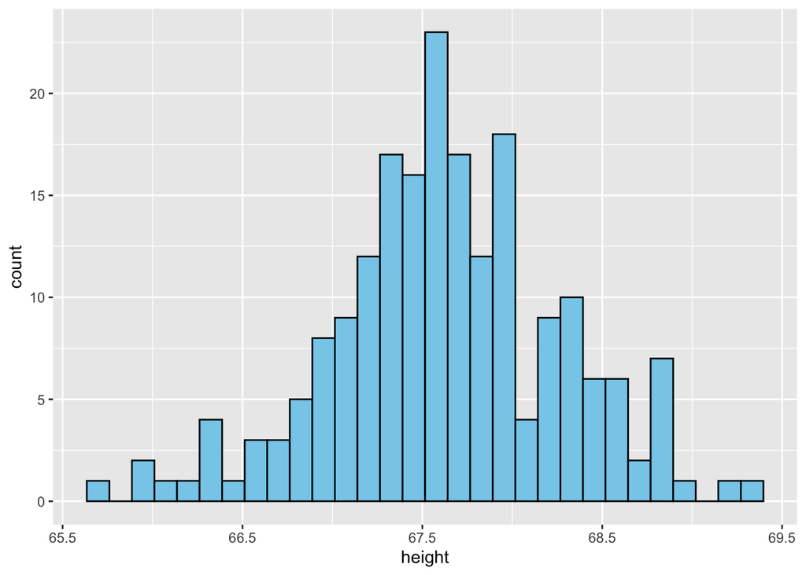

```r
z_sampling_distribution %>%
  ggplot(aes(x = height)) +
  geom_histogram(fill = "skyblue", color = "black")
```

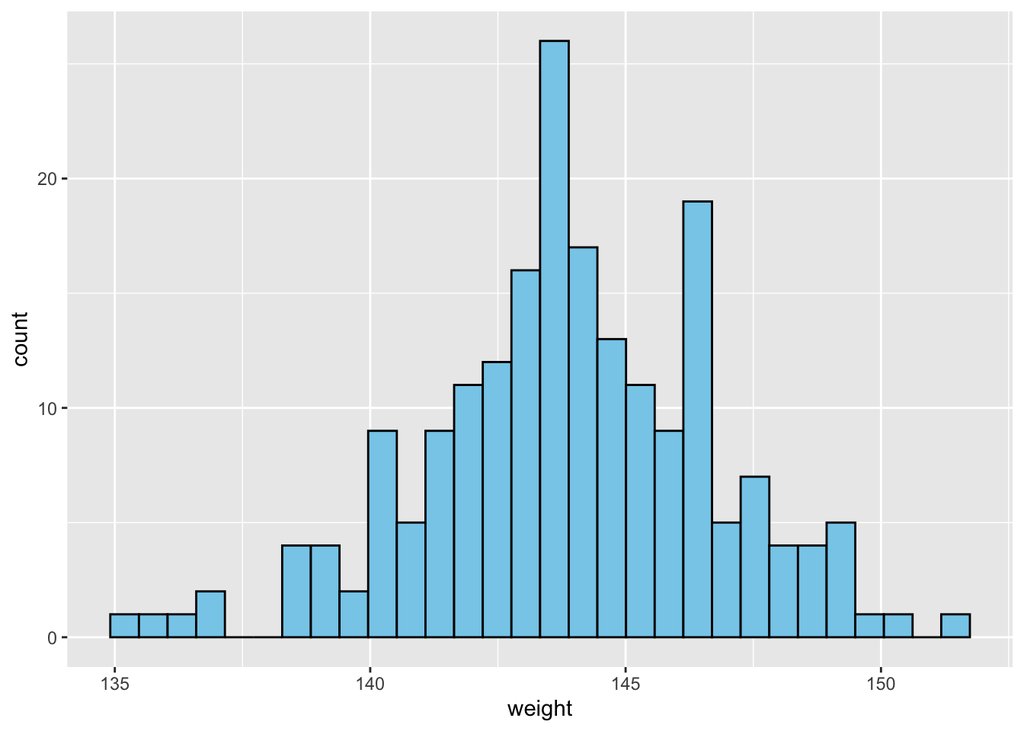

```r
z_sampling_distribution %>%
  ggplot(aes(x = weight)) +
  geom_histogram(fill = "skyblue", color = "black")
```

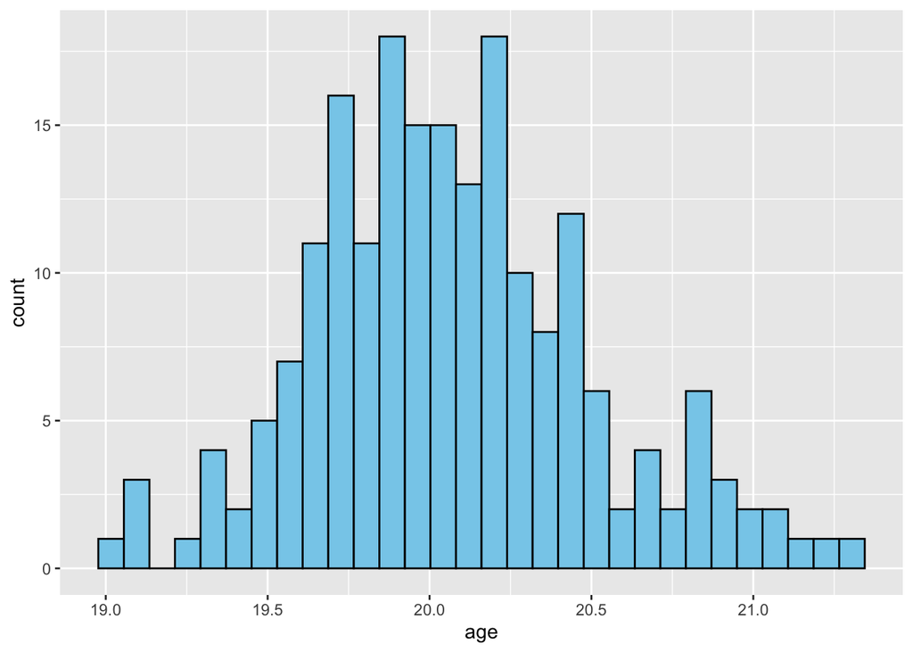

```r
z_sampling_distribution %>%
  ggplot(aes(x = age)) +
  geom_histogram(fill = "skyblue", color = "black")
```

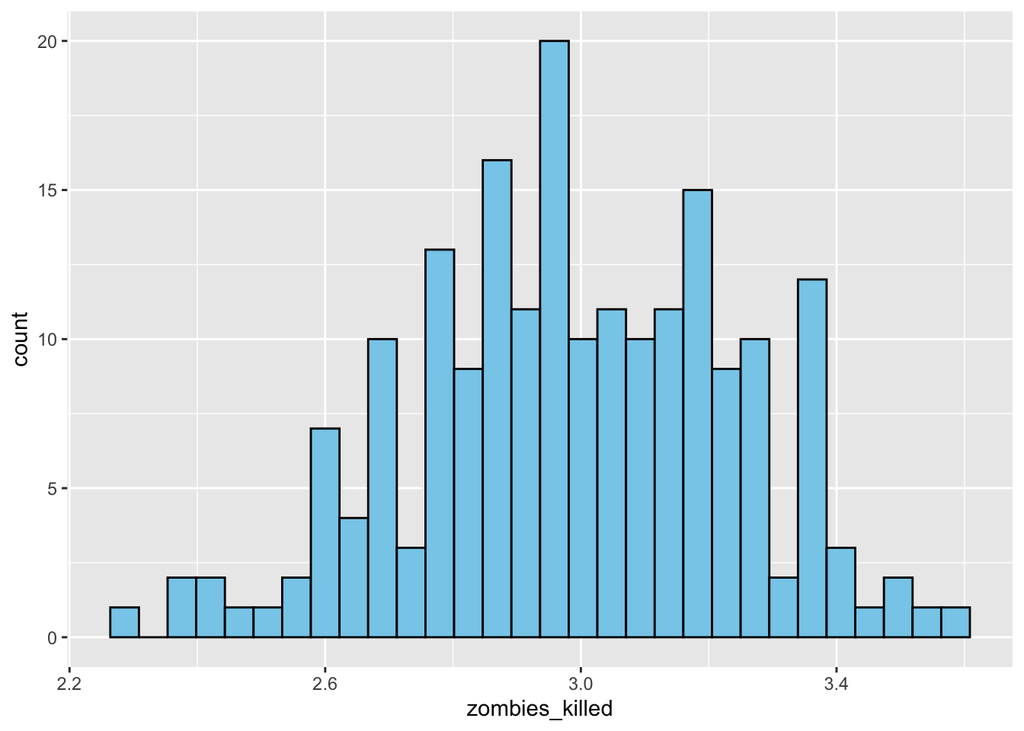

```r
z_sampling_distribution %>%
  ggplot(aes(x = zombies_killed)) +
  geom_histogram(fill = "skyblue", color = "black")
```

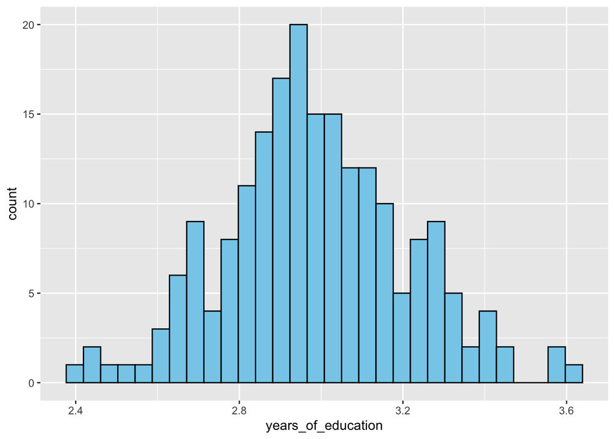

```r
z_sampling_distribution %>%
  ggplot(aes(x = years_of_education)) +
  geom_histogram(fill = "skyblue", color = "black")
```

## Step 9

Construct a 95% confidence interval for each mean directly from the sampling distribution of sample means using the central 95% that distribution (i.e., by setting the lower and upper CI bounds to 2.5% and 97.5% of the way through that distribution). How do the various 95% CIs you estimated compare to one another (i.e., the CI based on one sample and the corresponding sample standard deviation versus the CI based on simulation where you created a sampling distribution across 200 samples)?

```r
ci_results <- z_sampling_distribution %>%
  summarise(across(
    everything(),
    list(
      CI_lower = ~ quantile(., 0.025, na.rm = TRUE),
      CI_upper = ~ quantile(., 0.975, na.rm = TRUE)
    )
  ))

t(ci_results %>% select(-c(.row_CI_lower,.row_CI_upper,.index_CI_lower,.index_CI_upper)))
```

```
##                                  [,1]
## height_CI_lower              66.32016
## height_CI_upper              68.83832
## weight_CI_lower             138.44110
## weight_CI_upper             149.04585
## age_CI_lower                 19.29164
## age_CI_upper                 21.00882
## zombies_killed_CI_lower       2.47800
## zombies_killed_CI_upper       3.42100
## years_of_education_CI_lower   2.55900
## years_of_education_CI_upper   3.40100
```

```r
z_sample50_stats$height_sample_mean + qnorm(c(0.025, 0.975)) * z_sample50_stats$height_sample_SE
```

```
## [1] 66.35698 68.88654
```

```r
z_sample50_stats$weight_sample_mean + qnorm(c(0.025, 0.975)) * z_sample50_stats$weight_sample_SE
```

```
## [1] 134.7455 146.0152
```

```r
z_sample50_stats$age_sample_mean + qnorm(c(0.025, 0.975)) * z_sample50_stats$age_sample_SE
```

```
## [1] 19.67436 21.26639
```

```r
z_sample50_stats$zombies_killed_sample_mean + qnorm(c(0.025, 0.975)) * z_sample50_stats$zombies_killed_sample_SE
```

```
## [1] 2.639411 3.480589
```

```r
z_sample50_stats$years_of_education_sample_mean + qnorm(c(0.025, 0.975)) * z_sample50_stats$years_of_education_sample_SE
```

```
## [1] 2.17955 3.14045
```

## Step 10

Finally, use bootstrapping to generate a 95% confidence interval for each variable mean by resampling 1000 samples, with replacement, from your original sample (i.e., by setting the lower and upper CI bounds to 2.5% and 97.5% of the way through the sampling distribution generated by bootstrapping). How does this compare to the CIs generated in Step 9?

All three results show very similar estimates.

```r
library(mosaic)

n_boot <- 1000
n <- 50
boot <- do(n_boot) * summarise(
  sample_n(z, n, replace = TRUE),
  height_mean = mean(height),
  weight_mean = mean(weight),
  age_mean = mean(age),
  zombies_killed_mean = mean(zombies_killed),
  years_of_education_mean = mean(years_of_education)
)

boot_ci <- boot %>%
  summarise(across(everything(), list(
    CI_lower = ~ quantile(., 0.025, na.rm = TRUE),
    CI_upper = ~ quantile(., 0.975, na.rm = TRUE)
    )
  ))

t(boot_ci %>% select(-c(.row_CI_lower,.row_CI_upper,.index_CI_lower,.index_CI_upper)))
```

```
##                                       [,1]
## height_mean_CI_lower              66.43991
## height_mean_CI_upper              68.83133
## weight_mean_CI_lower             138.69673
## weight_mean_CI_upper             148.71824
## age_mean_CI_lower                 19.22895
## age_mean_CI_upper                 20.86367
## zombies_killed_mean_CI_lower       2.50000
## zombies_killed_mean_CI_upper       3.46050
## years_of_education_mean_CI_lower   2.52000
## years_of_education_mean_CI_upper   3.42050
```